# Estudis d'Informàtica, Multimedia i Telecomunicacions

# Mineria de dades: PAC1

Autor: Jordi Puig Ovejero

Març 2020

# 1 Exercici:

Estudia els tres casos següents i contesta justificant a la pregunta que es realitza:

## 1.1 Cas1

*Disposem d’un conjunt de variables referents a vehicles, tals com la marca, model, any de matriculació, etc. També es té el preu al qual es van vendre. Donat un nou vehicle posat a la venda, del qual es tenen les variables, però es desconeix el preu, quin tipus d’algorisme s’hauria d’aplicar per a predir de forma automàtica el preu?*

En aquest cas faria servir algoritmes predictius, ja que volem predir un valor de sortida a partir d’unes variables d’entrada.

Podríem fer servir la regressió on establim una funció de regressió de les variables d’entrada (marca, model, any de matriculació…) amb la variable objectiu, en aquest cas el preu.

## 1.2 Cas2

*En un magatzem de taronges es té una màquina que de forma automàtica obté un conjunt de variables de cada taronja, com la seva grandària, acidesa, grau maduració, etc. Si es desitja estudiar les taronges en diferents tipus segons les variables obtingudes, quin tipus d’algorisme és el més adequat?*

La tècnica de data mining que faria servir seria una tècnica per a processos descriptius, ja que volem agrupar les taronges amb característiques similars.

Com que no tenim grups predefinits haurem de fer servir la tècnica de clustering, amb la que trobarem grups similars a partir de les seves característiques.

Un cop tinguéssim grups ja definits de taronges i volguéssim estudiar atributs d’aquests grups, podríem fer servir tècniques de classificació (xarxes neuronals, arbres de decisió o regles de classificació). Aquí hem de tenir prèviament coneixement sobre el domini.

## 1.3 Cas3

*Un servei de música per internet disposa dels historials de escolta dels seus clients: Quines cançons i grups trien els clients al llarg del temps de les seves escoltes. L’empresa desitja crear un sistema d’escolta que proposi la següent cançó i grup en funció de l’anterior escoltada. Quin tipus d’algorisme és el més adequat?*

A partir de diferents atributs tant de la darrera cançó, com del grup que la interpreta podem trobar diferents etiquetes o atributs:

- En els grups: tipus de música, època, estètica dels grups, país de procedència, …
- En les cançons: durada, idioma, tempo, ritme, volum, popularitat, contingut de la lletra, quantitat de lletra, acústica?..

Amb aquests atributs podem aplicar una classificació dels elements per a després predir la cançó següent relacionada amb l’anterior.

Segurament es podria també realitzar algun tipus d’aprenentatge si la cançó suggerida és omitida per l’usuari que està escoltant.

# 2 Exercici:

A partir del joc de dades disponible en el següent enllaç http://archive.ics.uci.edu/ml/datasets/adult , realitza un estudi prenent com a proposta inicial el que s’ha realitzat amb el joc de dades “Titànic”. Amplia la proposta generant nous indicadors o solucionant altres problemes exposats en el mòdul 2. Explica el procés que has seguit, quin coneixement obtens de les dades, quin objectiu t’has fixat i detalla els passos, tècniques usades i els problemes resolts.

Nota: Si ho desitges pots utilitzar un altre conjunt de dades propi o d’algun repositori dades obertes sempre que sigui similar en diversitat de tipus de variables al proposat.

## 2.1 Enunciat

Com a mostra, treballarem amb el joc de dades “Adult Data Set” que recull dades de cens sobre la població dels EEUU i fa una predicció que avalua si els ingressos estan per sobre del $50 l’any.

- Número d’instàncies: 48842
- Tipus d’atributs: Categòric i Enter
- Nombre d’atributs: 14
- Any del cens: 1994
- Missing values: Sí

## 2.2 Font

http://archive.ics.uci.edu/ml/datasets/adult

Ronny Kohavi and Barry Becker Data Mining and Visualization Silicon Graphics.

## 2.3 Processos de neteja del joc de dades

Primer contacte amb el joc de dades, visualitzem la seva estructura.

```r
# Carreguem els paquets R que utilitzarem
library(ggplot2)
library(dplyr)
library(scales)
library(dplyr)

# Carreguem el fitxer de dades
totalData <- read.csv('adult.csv', stringsAsFactors = FALSE)
filas=dim(totalData)[1]


# Verifiquem l'estructura del joc de dades
str(totalData)
```

```
## 'data.frame':    32561 obs. of  15 variables:
##  $ age           : int  39 50 38 53 28 37 49 52 31 42 ...
##  $ workclass     : chr  "State-gov" "Self-emp-not-inc" "Private" "Private" ...
##  $ fnlwgt        : int  77516 83311 215646 234721 338409 284582 160187 209642 45781 159449 ...
##  $ education     : chr  "Bachelors" "Bachelors" "HS-grad" "11th" ...
##  $ education.num : int  13 13 9 7 13 14 5 9 14 13 ...
##  $ marital.status: chr  "Never-married" "Married-civ-spouse" "Divorced" "Married-civ-spouse" ...
##  $ occupation    : chr  "Adm-clerical" "Exec-managerial" "Handlers-cleaners" "Handlers-cleaners" ...
##  $ relationship  : chr  "Not-in-family" "Husband" "Not-in-family" "Husband" ...
##  $ race          : chr  "White" "White" "White" "Black" ...
##  $ sex           : chr  "Male" "Male" "Male" "Male" ...
##  $ capital.gain  : int  2174 0 0 0 0 0 0 0 14084 5178 ...
##  $ capital.loss  : int  0 0 0 0 0 0 0 0 0 0 ...
##  $ hours.per.week: int  40 13 40 40 40 40 16 45 50 40 ...
##  $ native.country: chr  "United-States" "United-States" "United-States" "United-States" ...
##  $ exceed        : chr  "<=50K" "<=50K" "<=50K" "<=50K" ...
```

### 2.3.2 Traiem estadístiques bàsiques

```r
# Estadístiques bàsiques
summary(totalData)
```

```
##       age         workclass             fnlwgt         education
##  Min.   :17.00   Length:32561       Min.   :  12285   Length:32561
##  1st Qu.:28.00   Class :character   1st Qu.: 117827   Class :character
##  Median :37.00   Mode  :character   Median : 178356   Mode  :character
##  Mean   :38.58                      Mean   : 189778
##  3rd Qu.:48.00                      3rd Qu.: 237051
##  Max.   :90.00                      Max.   :1484705
##  education.num   marital.status      occupation        relationship
##  Min.   : 1.00   Length:32561       Length:32561       Length:32561
##  1st Qu.: 9.00   Class :character   Class :character   Class :character
##  Median :10.00   Mode  :character   Mode  :character   Mode  :character
##  Mean   :10.08
##  3rd Qu.:12.00
##  Max.   :16.00
##      race               sex             capital.gain    capital.loss
##  Length:32561       Length:32561       Min.   :    0   Min.   :   0.0
##  Class :character   Class :character   1st Qu.:    0   1st Qu.:   0.0
##  Mode  :character   Mode  :character   Median :    0   Median :   0.0
##                                        Mean   : 1078   Mean   :  87.3
##                                        3rd Qu.:    0   3rd Qu.:   0.0
##                                        Max.   :99999   Max.   :4356.0
##  hours.per.week  native.country        exceed
##  Min.   : 1.00   Length:32561       Length:32561
##  1st Qu.:40.00   Class :character   Class :character
##  Median :40.00   Mode  :character   Mode  :character
##  Mean   :40.44
##  3rd Qu.:45.00
##  Max.   :99.00
```

### 2.3.3 Tractament dels valors buits

```r
# El document adult.data té els valor buits transformats a '?'
# Per tant no hi ha cap com a buit (missign value)
colSums(is.na(totalData))
```

```
##            age      workclass         fnlwgt      education  education.num
##              0              0              0              0              0
## marital.status     occupation   relationship           race            sex
##              0              0              0              0              0
##   capital.gain   capital.loss hours.per.week native.country         exceed
##              0              0              0              0              0
```

```r
# Però si amb el valor ja transformat a '?'
colSums(totalData=="?")
```

```
##            age      workclass         fnlwgt      education  education.num
##              0           1836              0              0              0
## marital.status     occupation   relationship           race            sex
##              0           1843              0              0              0
##   capital.gain   capital.loss hours.per.week native.country         exceed
##              0              0              0            583              0
```

```r
# Tenim elements buits a workclass, occupation, native.country
# Comprovem quant respresenten respecte al total
total <- nrow(totalData)
# Percentatge de buits de workclass
turnover <- nrow(subset(totalData, workclass == "?")) / total
pctworkclass <- percent(turnover, accuracy = 0.01)
pctworkclass
```

```
## [1] "5.64%"
```

```r
# Percentatge de buits de l'atribut occupation respecte el total
turnover <- nrow(subset(totalData, occupation == "?")) / total
pctoccupation <- percent(turnover, accuracy = 0.01)
pctoccupation
```

```
## [1] "5.66%"
```

```r
# Percentatge de buits de l'atribut native.country respecte el total
turnover <- nrow(subset(totalData, native.country == "?")) / total
pctcountry <- percent(turnover, accuracy = 0.01)
pctcountry
```

```
## [1] "1.79%"
```

```r
# En principi no modificarem els valors buits. Agafarem subconjunts a l'hora de tractar les dades, és a dir, ometrem registres amb valor '?' per als estudis.
subset <- subset(totalData, native.country != "?")
subset <- subset(subset, occupation != "?")
subset <- subset(subset, workclass != "?")
# Ara subset no te els valors amb elements "?". De totes maneres, treballem amb totalData i els eliminarem quan toqui.
```

### 2.3.4 Discretització

Discretitzem els valors categòrics

```r
# Mirem el nombre d'elements diferents per a cada classe
apply(totalData,2, function(x) length(unique(x)))
```

```
##            age      workclass         fnlwgt      education  education.num
##             73              9          21648             16             16
## marital.status     occupation   relationship           race            sex
##              7             15              6              5              2
##   capital.gain   capital.loss hours.per.week native.country         exceed
##            119             92             94             42              2
```

```r
# Discretitzem les variables amb poques classes. Podríem discretitzar "education" per ja ho està
cols<-c("marital.status","relationship","race","sex", "occupation", "exceed", "workclass")
for (i in cols){
  totalData[,i] <- as.factor(totalData[,i])
}

# Després dels canvis, analitzem la nova estructura del joc de dades
str(totalData)
```

```
## 'data.frame':    32561 obs. of  15 variables:
##  $ age           : int  39 50 38 53 28 37 49 52 31 42 ...
##  $ workclass     : Factor w/ 9 levels "?","Federal-gov",..: 8 7 5 5 5 5 5 7 5 5 ...
##  $ fnlwgt        : int  77516 83311 215646 234721 338409 284582 160187 209642 45781 159449 ...
##  $ education     : chr  "Bachelors" "Bachelors" "HS-grad" "11th" ...
##  $ education.num : int  13 13 9 7 13 14 5 9 14 13 ...
##  $ marital.status: Factor w/ 7 levels "Divorced","Married-AF-spouse",..: 5 3 1 3 3 3 4 3 5 3 ...
##  $ occupation    : Factor w/ 15 levels "?","Adm-clerical",..: 2 5 7 7 11 5 9 5 11 5 ...
##  $ relationship  : Factor w/ 6 levels "Husband","Not-in-family",..: 2 1 2 1 6 6 2 1 2 1 ...
##  $ race          : Factor w/ 5 levels "Amer-Indian-Eskimo",..: 5 5 5 3 3 5 3 5 5 5 ...
##  $ sex           : Factor w/ 2 levels "Female","Male": 2 2 2 2 1 1 1 2 1 2 ...
##  $ capital.gain  : int  2174 0 0 0 0 0 0 0 14084 5178 ...
##  $ capital.loss  : int  0 0 0 0 0 0 0 0 0 0 ...
##  $ hours.per.week: int  40 13 40 40 40 40 16 45 50 40 ...
##  $ native.country: chr  "United-States" "United-States" "United-States" "United-States" ...
##  $ exceed        : Factor w/ 2 levels "<=50K",">50K": 1 1 1 1 1 1 1 2 2 2 ...
```

## 2.4 Processos d’anàlisis del joc de dades

### 2.4.1 Vegem un exemple de construcció d’un atribut nou: “exceed” com a boolean

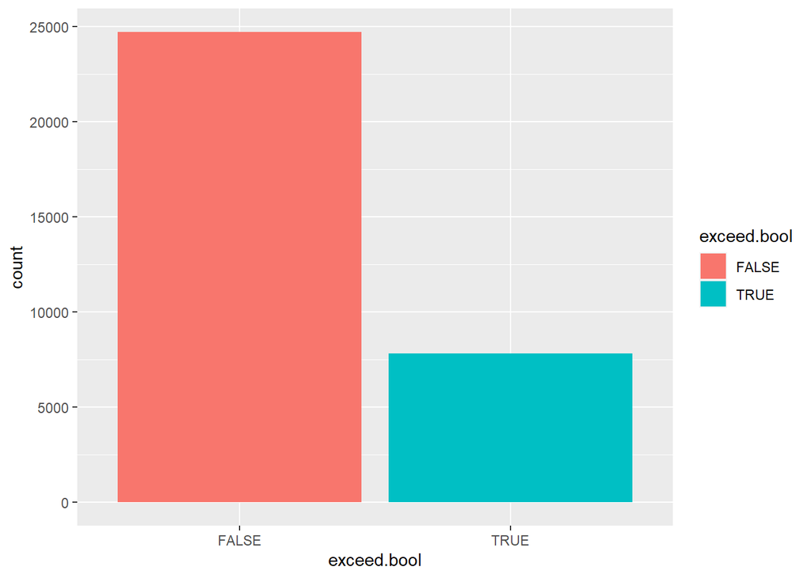

```r
# Construïm un atribut nou: "exceed.bool"
# Boolean per indicar si té una prediccio de superar els $50K i mostrem gràfic respecte aquesta variable.
totalData$exceed.bool <- totalData$exceed == ">50K"
ggplot(data=totalData[1:filas,],aes(x=exceed.bool,fill=exceed.bool))+geom_bar()
```

La proporció d’usuaris que excedeixen és força inferior als que no.

### 2.4.2 Relació entre “exceed” i “sex”

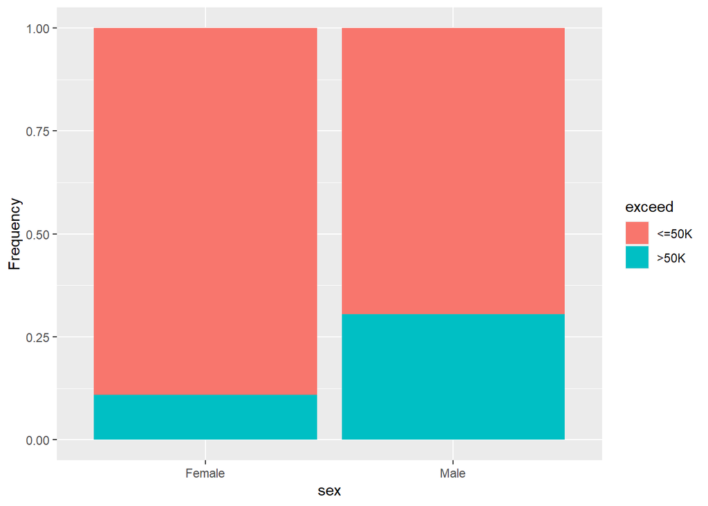

```r
# Ara veiem la relació en funció del sexe
ggplot(data=totalData[1:filas,],aes(x=sex,fill=exceed)) + geom_bar(position="fill") + ylab("Frequency")
```

Com era de preveure la proporció dels elements que superen els $50K és molt superior en els homes que en les dones, més tenint en compte que la mostra té més de 20 anys, és dels anys 90 on aquestes diferències eran més grans.

### 2.4.3 Relació entre “exceed” i “race”

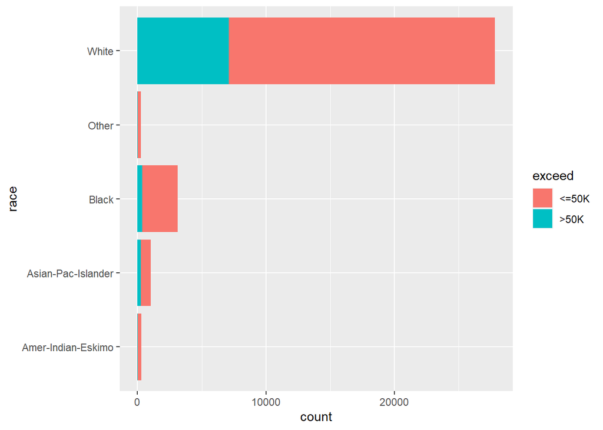

```r
# variable exceed en funció de la raça
ggplot(data=totalData[1:filas,],aes(x=race,fill=exceed)) + geom_bar() + coord_flip()
```

Si *normalitzem* l’atribut “race”

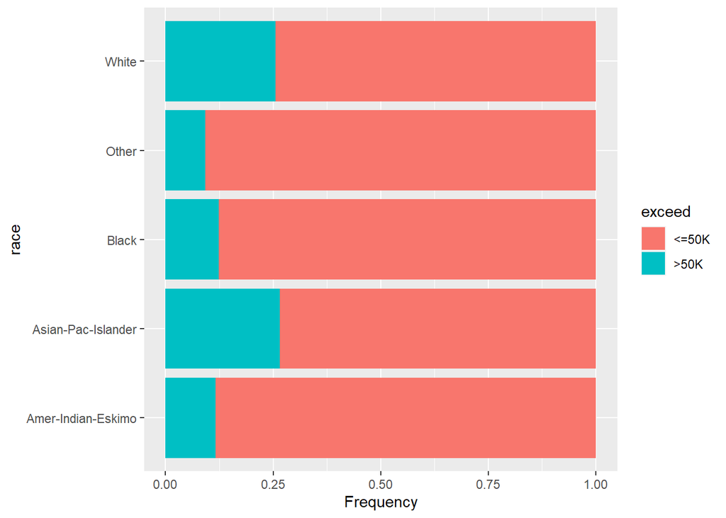

```r
# Variable nova amb l'atribut 'race' normalitzat en una escala 0,1
ggplot(data=totalData[1:filas,],aes(x = race, fill=exceed)) + geom_bar(position="fill") + ylab("Frequency")+ coord_flip()
```

Al normalitzar veiem realment la proporció real i no hi ha tanta diferència proporcional entre els blancs i els asiàtics. Sí amb la resta de categories.

### 2.4.4 Relació entre “exceed” i “marital.status”

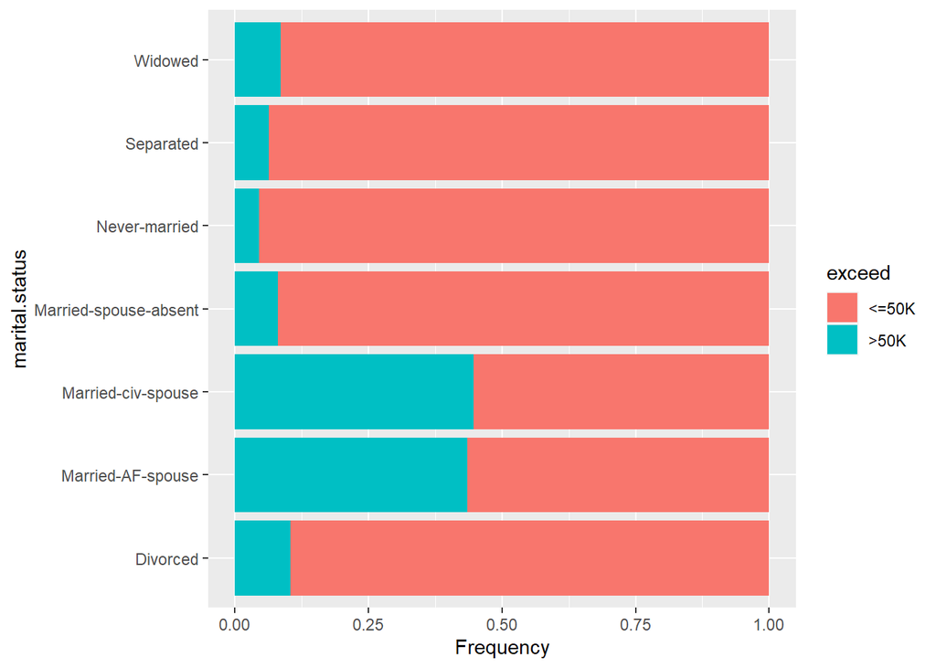

```r
# variable exceed en funció de marital.status
ggplot(data=totalData[1:filas,],aes(x=marital.status,fill=exceed)) + geom_bar(position="fill") + ylab("Frequency")+ coord_flip()
```

Com a curiositat, sembla que les “famílies tipus” de llavors tenen més opcions d’arribar a aquests salaris que no pas altres.

### 2.4.5 Relació entre “exceed” i “education”

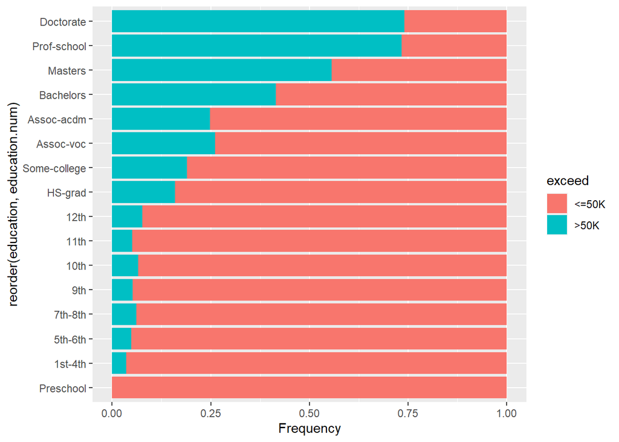

```r
# variable exceed en funció de education
# primer ordenem per education.num ascendent entenent que aquest valor indicarà el nivell d'estudis
ggplot(data=totalData[1:filas,],aes(x=reorder(education, education.num) ,fill=exceed)) + geom_bar(position="fill") + ylab("Frequency")+ coord_flip()
```

La relació entre el nivell d’estudis i excedir els $50K és molt gràfica.

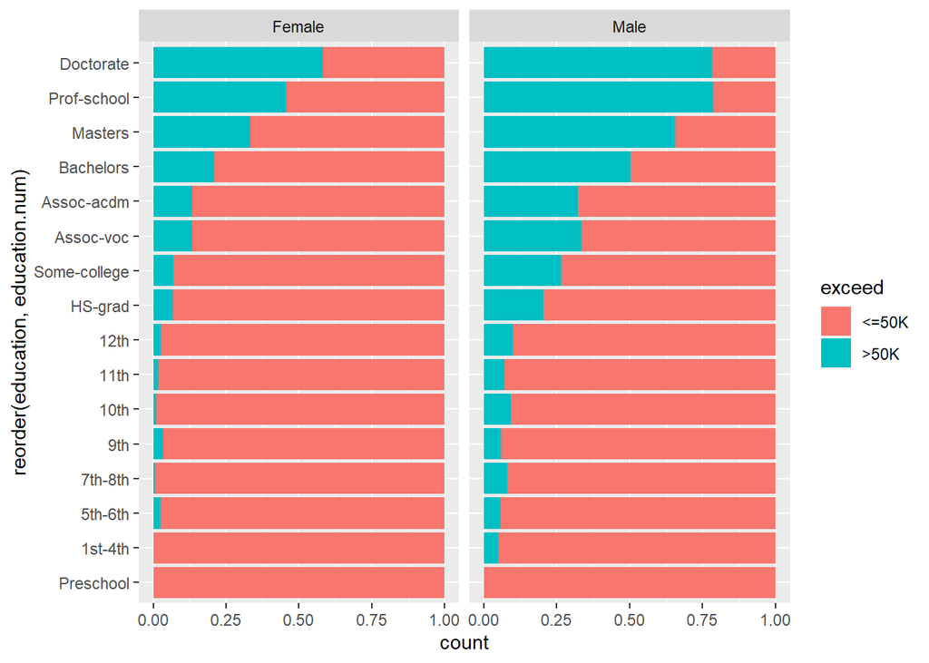

```r
# ara li afegim la variable sexe
ggplot(data = totalData[1:filas,],aes(x=reorder(education, education.num),fill=exceed))+geom_bar(position="fill")+facet_wrap(~sex)+ coord_flip()
```

No canvia gaire moltíssim la forma, però has de tenir més formació per ser dona i superar els $50K

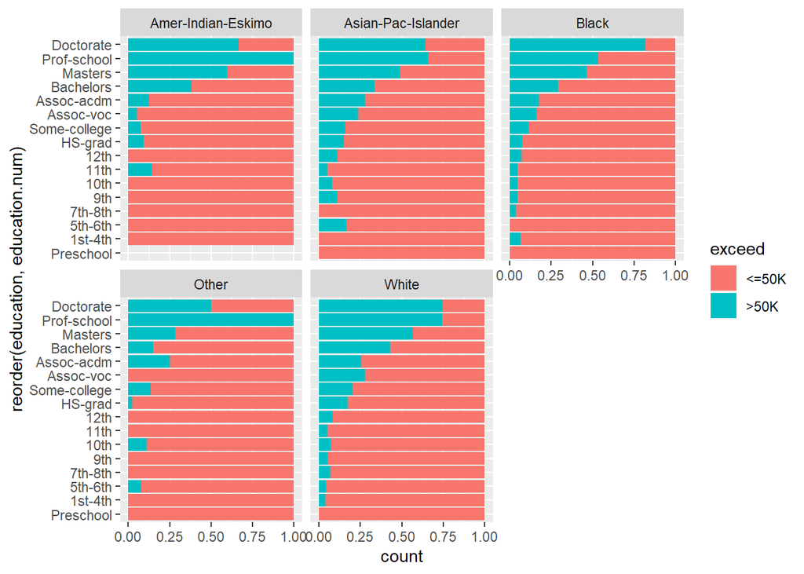

```r
# el mateix d'abans però amb "race"
ggplot(data = totalData[1:filas,],aes(x=reorder(education, education.num),fill=exceed))+geom_bar(position="fill")+facet_wrap(~race)+ coord_flip()
```